Eat 4 Life Marketing · AI Marketing Made Easy

# AI Search Visibility Report — The Chicago Dental Studio

Chicago, IL · Dental · October 2026 · baseline audit

We asked **ChatGPT, Gemini, Perplexity, and Claude** the 7 questions your customers actually type when they're ready to buy — fresh sessions, no history, just like a real person. AI already names The Chicago Dental Studio in 7 answers — the plan below grows that number.

## Platform by platform

ChatGPT

0/7

Answered 7 of 7 questions and never mentioned The Chicago Dental Studio.

Gemini

1/7

Recommends The Chicago Dental Studio on 1 of 7 questions.

Perplexity

4/7

Recommends The Chicago Dental Studio on 4 of 7 questions.

Claude

2/7

Recommends The Chicago Dental Studio on 2 of 7 questions.

## Question by question

| What your customers ask AI | ChatGPT | Gemini | Perplexity | Claude |
| --- | --- | --- | --- | --- |
| best dentist in Chicago, IL | — | — | ✓ | ✓ |
| emergency dentist near Chicago, IL | — | — | ✗ | — |
| Chicago, IL dentist good with anxious patients | — | — | ✓ | — |
| invisalign Chicago, IL | — | — | ✓ | — |
| best cosmetic dentist Chicago, IL | — | ✓ | ✓ | ✓ |
| dentist taking new patients Chicago, IL | — | — | ✗ | — |
| pediatric dentist near Chicago, IL | — | — | — | — |

✓ The Chicago Dental Studio named · — answered, not named · ✗ not tested this run

## Who AI recommends instead

Across all answers this month, these businesses were named — each mention is a customer conversation happening without you:

- **Smile Science Chicago** — named 5×
- **Chicago Style Smiles** — named 4×
- **Chicago Loop Dentistry** — named 4×
- **Marcus Dental Practice** — named 3×
- **Mitchell Dental Spa** — named 3×
- **Downtown Dental** — named 3×
- **Chicago Smile Design** — named 3×
- **Strobel Dentistry** — named 3×

## The receipts

Exactly what the AI said, captured the moment we asked:

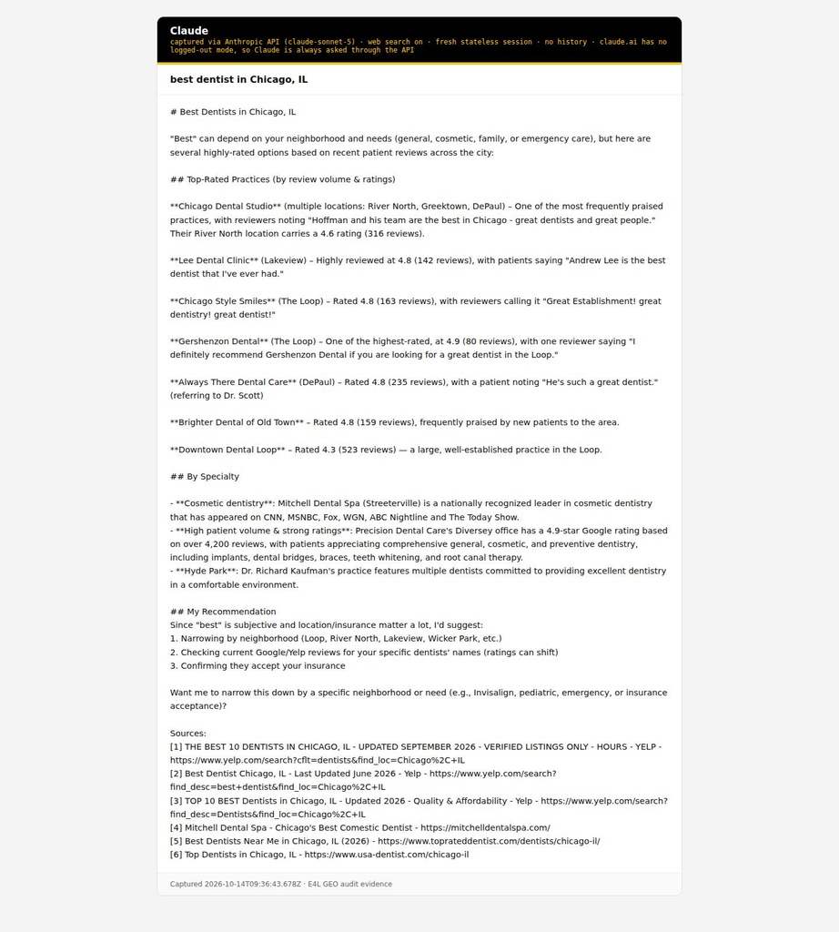

Claude — “best dentist in Chicago, IL” — The Chicago Dental Studio is named.

[figure not shown]

Claude — “best cosmetic dentist Chicago, IL” — The Chicago Dental Studio is named.

[figure not shown]

Gemini — “best cosmetic dentist Chicago, IL” — The Chicago Dental Studio is named.

[figure not shown]

Perplexity — “best dentist in Chicago, IL” — The Chicago Dental Studio is named.

[figure not shown]

ChatGPT — “best dentist in Chicago, IL” — others are recommended; The Chicago Dental Studio is absent.

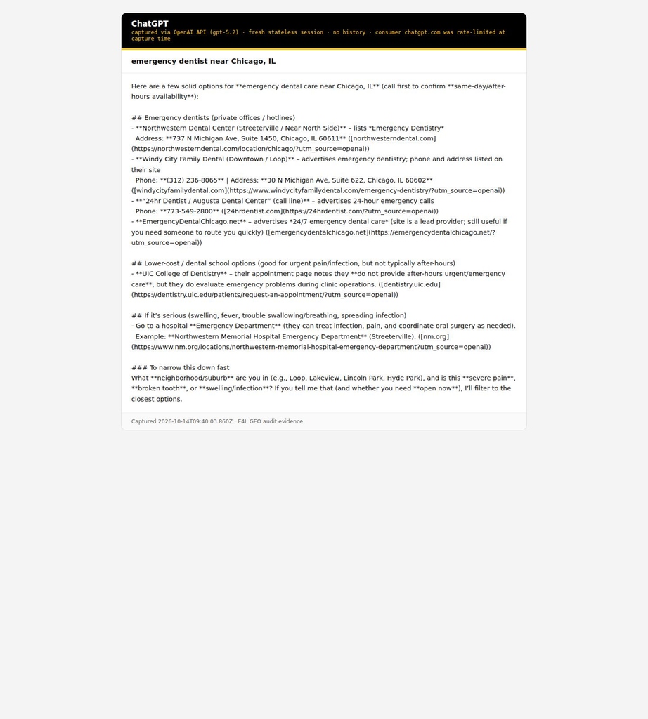

ChatGPT — “emergency dentist near Chicago, IL” — others are recommended; The Chicago Dental Studio is absent.